# Risk Factor Analysis

## Outcome Variable

**Outcome Variable:** ever_co

## Predictor Variables

**Intervention Variable:** gagebrth

**Adjustment Set:**

- arm
- sex
- W_mage
- meducyrs
- feducyrs
- hhwealth_quart
- single
- brthmon
- W_parity
- delta_W_mage
- delta_meducyrs
- delta_feducyrs
- delta_hhwealth_quart
- delta_single
- delta_brthmon
- delta_W_parity

## Stratifying Variables

The analysis was stratified on these variable(s):

- agecat
- studyid
- country

## Data Summary

| agecat | studyid | country | gagebrth | ever_co | n_cell | n |
| --- | --- | --- | --- | --- | --- | --- |
| 0-24 months | ki1000108-CMC-V-BCS-2002 | INDIA | Full or late term | 0 | 170 | 351 |
| 0-24 months | ki1000108-CMC-V-BCS-2002 | INDIA | Full or late term | 1 | 45 | 351 |
| 0-24 months | ki1000108-CMC-V-BCS-2002 | INDIA | Preterm | 0 | 35 | 351 |
| 0-24 months | ki1000108-CMC-V-BCS-2002 | INDIA | Preterm | 1 | 17 | 351 |
| 0-24 months | ki1000108-CMC-V-BCS-2002 | INDIA | Early term | 0 | 70 | 351 |
| 0-24 months | ki1000108-CMC-V-BCS-2002 | INDIA | Early term | 1 | 14 | 351 |
| 0-24 months | ki1000108-IRC | INDIA | Full or late term | 0 | 211 | 390 |
| 0-24 months | ki1000108-IRC | INDIA | Full or late term | 1 | 39 | 390 |
| 0-24 months | ki1000108-IRC | INDIA | Preterm | 0 | 28 | 390 |
| 0-24 months | ki1000108-IRC | INDIA | Preterm | 1 | 14 | 390 |
| 0-24 months | ki1000108-IRC | INDIA | Early term | 0 | 78 | 390 |
| 0-24 months | ki1000108-IRC | INDIA | Early term | 1 | 20 | 390 |
| 0-24 months | ki1000109-EE | PAKISTAN | Full or late term | 0 | 21 | 379 |
| 0-24 months | ki1000109-EE | PAKISTAN | Full or late term | 1 | 4 | 379 |
| 0-24 months | ki1000109-EE | PAKISTAN | Preterm | 0 | 145 | 379 |
| 0-24 months | ki1000109-EE | PAKISTAN | Preterm | 1 | 100 | 379 |
| 0-24 months | ki1000109-EE | PAKISTAN | Early term | 0 | 69 | 379 |
| 0-24 months | ki1000109-EE | PAKISTAN | Early term | 1 | 40 | 379 |
| 0-24 months | ki1000304b-SAS-CompFeed | INDIA | Full or late term | 0 | 21 | 1498 |
| 0-24 months | ki1000304b-SAS-CompFeed | INDIA | Full or late term | 1 | 7 | 1498 |
| 0-24 months | ki1000304b-SAS-CompFeed | INDIA | Preterm | 0 | 1044 | 1498 |
| 0-24 months | ki1000304b-SAS-CompFeed | INDIA | Preterm | 1 | 321 | 1498 |
| 0-24 months | ki1000304b-SAS-CompFeed | INDIA | Early term | 0 | 85 | 1498 |
| 0-24 months | ki1000304b-SAS-CompFeed | INDIA | Early term | 1 | 20 | 1498 |
| 0-24 months | ki1017093c-NIH-Crypto | BANGLADESH | Full or late term | 0 | 161 | 758 |
| 0-24 months | ki1017093c-NIH-Crypto | BANGLADESH | Full or late term | 1 | 7 | 758 |
| 0-24 months | ki1017093c-NIH-Crypto | BANGLADESH | Preterm | 0 | 224 | 758 |
| 0-24 months | ki1017093c-NIH-Crypto | BANGLADESH | Preterm | 1 | 41 | 758 |
| 0-24 months | ki1017093c-NIH-Crypto | BANGLADESH | Early term | 0 | 302 | 758 |
| 0-24 months | ki1017093c-NIH-Crypto | BANGLADESH | Early term | 1 | 23 | 758 |

[output cut: 186 more lines]

The following strata were considered:

- agecat: 0-24 months, studyid: ki1000108-CMC-V-BCS-2002, country: INDIA
- agecat: 0-24 months, studyid: ki1000108-IRC, country: INDIA
- agecat: 0-24 months, studyid: ki1000109-EE, country: PAKISTAN
- agecat: 0-24 months, studyid: ki1000304b-SAS-CompFeed, country: INDIA
- agecat: 0-24 months, studyid: ki1017093c-NIH-Crypto, country: BANGLADESH
- agecat: 0-24 months, studyid: ki1066203-TanzaniaChild2, country: TANZANIA, UNITED REPUBLIC OF
- agecat: 0-24 months, studyid: ki1101329-Keneba, country: GAMBIA
- agecat: 0-24 months, studyid: ki1119695-PROBIT, country: BELARUS
- agecat: 0-24 months, studyid: ki1135781-COHORTS, country: GUATEMALA
- agecat: 0-24 months, studyid: ki1135781-COHORTS, country: INDIA
- agecat: 0-24 months, studyid: ki1135781-COHORTS, country: PHILIPPINES
- agecat: 0-24 months, studyid: kiGH5241-JiVitA-3, country: BANGLADESH
- agecat: 0-6 months, studyid: ki1000108-CMC-V-BCS-2002, country: INDIA
- agecat: 0-6 months, studyid: ki1000108-IRC, country: INDIA
- agecat: 0-6 months, studyid: ki1000109-EE, country: PAKISTAN
- agecat: 0-6 months, studyid: ki1000304b-SAS-CompFeed, country: INDIA
- agecat: 0-6 months, studyid: ki1017093c-NIH-Crypto, country: BANGLADESH
- agecat: 0-6 months, studyid: ki1066203-TanzaniaChild2, country: TANZANIA, UNITED REPUBLIC OF
- agecat: 0-6 months, studyid: ki1101329-Keneba, country: GAMBIA
- agecat: 0-6 months, studyid: ki1119695-PROBIT, country: BELARUS
- agecat: 0-6 months, studyid: ki1135781-COHORTS, country: GUATEMALA
- agecat: 0-6 months, studyid: ki1135781-COHORTS, country: INDIA
- agecat: 0-6 months, studyid: ki1135781-COHORTS, country: PHILIPPINES
- agecat: 0-6 months, studyid: kiGH5241-JiVitA-3, country: BANGLADESH
- agecat: 6-24 months, studyid: ki1000108-CMC-V-BCS-2002, country: INDIA
- agecat: 6-24 months, studyid: ki1000108-IRC, country: INDIA
- agecat: 6-24 months, studyid: ki1000109-EE, country: PAKISTAN
- agecat: 6-24 months, studyid: ki1000304b-SAS-CompFeed, country: INDIA
- agecat: 6-24 months, studyid: ki1017093c-NIH-Crypto, country: BANGLADESH
- agecat: 6-24 months, studyid: ki1066203-TanzaniaChild2, country: TANZANIA, UNITED REPUBLIC OF
- agecat: 6-24 months, studyid: ki1101329-Keneba, country: GAMBIA
- agecat: 6-24 months, studyid: ki1119695-PROBIT, country: BELARUS
- agecat: 6-24 months, studyid: ki1135781-COHORTS, country: GUATEMALA
- agecat: 6-24 months, studyid: ki1135781-COHORTS, country: INDIA
- agecat: 6-24 months, studyid: ki1135781-COHORTS, country: PHILIPPINES
- agecat: 6-24 months, studyid: kiGH5241-JiVitA-3, country: BANGLADESH

### Dropped Strata

Some strata were dropped due to rare outcomes:

- agecat: 0-24 months, studyid: ki1000109-EE, country: PAKISTAN
- agecat: 0-24 months, studyid: ki1119695-PROBIT, country: BELARUS
- agecat: 0-6 months, studyid: ki1000109-EE, country: PAKISTAN
- agecat: 0-6 months, studyid: ki1000304b-SAS-CompFeed, country: INDIA
- agecat: 0-6 months, studyid: ki1017093c-NIH-Crypto, country: BANGLADESH
- agecat: 0-6 months, studyid: ki1066203-TanzaniaChild2, country: TANZANIA, UNITED REPUBLIC OF
- agecat: 0-6 months, studyid: ki1119695-PROBIT, country: BELARUS
- agecat: 6-24 months, studyid: ki1000109-EE, country: PAKISTAN
- agecat: 6-24 months, studyid: ki1119695-PROBIT, country: BELARUS

## Methods Detail

We’re interested in the causal parameters $E[Y_a]$ for all values of $a \in \mathcal{A}$. These parameters represent the mean outcome if, possibly contrary to fact, we intervened to set all units to have $A=a$. Under the randomization and positivity assumptions, these are identified by the statistical parameters $\psi_a=E_W[E_{Y|A,W}(Y|A=a,W)]$. In addition, we’re interested in the mean of $Y$, $E[Y]$ under no intervention (the observed mean). We will estimate these parameters by using SuperLearner to fit the relevant likelihood factors – $E_{Y|A,W}(Y|A=a,W)$ and $p(A=a|W)$, and then updating our likelihood fit using a joint TMLE.

For unadjusted analyses ($W=\{\}$), initial likelihoods were estimated using Lrnr_glm to estimate the simple $E(Y|A)$ and Lrnr_mean to estimate $p(A)$. For adjusted analyses, a small library containing Lrnr_glmnet, Lrnr_xgboost, and Lrnr_mean was used.

Having estimated these parameters, we will then use the delta method to estimate relative risks and attributable risks relative to a prespecified baseline level of $A$.

# Results Detail

## Results Plots

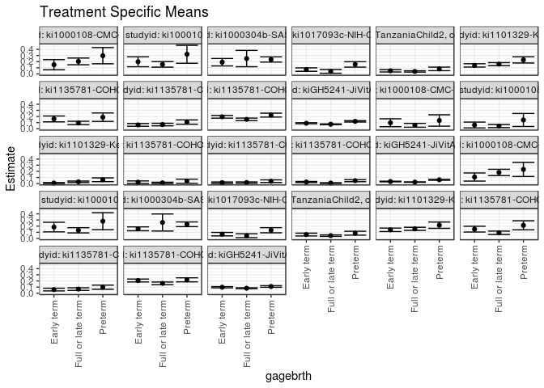

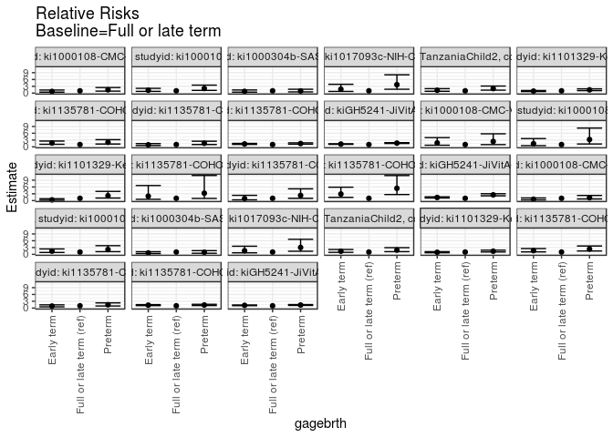

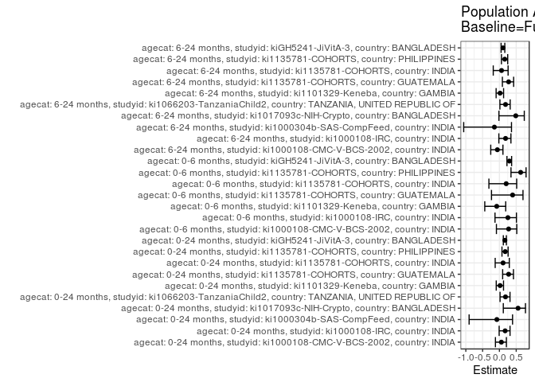

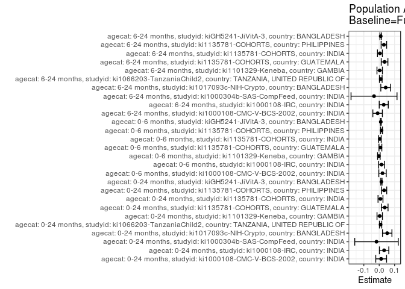

## Results Table

### Parameter: TSM

| agecat | studyid | country | intervention_level | baseline_level | estimate | ci_lower | ci_upper |
| --- | --- | --- | --- | --- | --- | --- | --- |
| 0-24 months | ki1000108-CMC-V-BCS-2002 | INDIA | Full or late term | NA | 0.2038610 | 0.1489810 | 0.2587410 |
| 0-24 months | ki1000108-CMC-V-BCS-2002 | INDIA | Preterm | NA | 0.2973186 | 0.1656144 | 0.4290227 |
| 0-24 months | ki1000108-CMC-V-BCS-2002 | INDIA | Early term | NA | 0.1502454 | 0.0675164 | 0.2329744 |
| 0-24 months | ki1000108-IRC | INDIA | Full or late term | NA | 0.1554026 | 0.1103332 | 0.2004719 |
| 0-24 months | ki1000108-IRC | INDIA | Preterm | NA | 0.3196169 | 0.1735654 | 0.4656684 |
| 0-24 months | ki1000108-IRC | INDIA | Early term | NA | 0.1978909 | 0.1171782 | 0.2786035 |
| 0-24 months | ki1000304b-SAS-CompFeed | INDIA | Full or late term | NA | 0.2500000 | 0.1173954 | 0.3826046 |
| 0-24 months | ki1000304b-SAS-CompFeed | INDIA | Preterm | NA | 0.2351648 | 0.1926748 | 0.2776548 |
| 0-24 months | ki1000304b-SAS-CompFeed | INDIA | Early term | NA | 0.1904762 | 0.1298989 | 0.2510534 |
| 0-24 months | ki1017093c-NIH-Crypto | BANGLADESH | Full or late term | NA | 0.0416667 | 0.0114301 | 0.0719033 |
| 0-24 months | ki1017093c-NIH-Crypto | BANGLADESH | Preterm | NA | 0.1547170 | 0.1111476 | 0.1982864 |
| 0-24 months | ki1017093c-NIH-Crypto | BANGLADESH | Early term | NA | 0.0707692 | 0.0428710 | 0.0986675 |
| 0-24 months | ki1066203-TanzaniaChild2 | TANZANIA, UNITED REPUBLIC OF | Full or late term | NA | 0.0407317 | 0.0303209 | 0.0511425 |
| 0-24 months | ki1066203-TanzaniaChild2 | TANZANIA, UNITED REPUBLIC OF | Preterm | NA | 0.0820553 | 0.0531945 | 0.1109161 |
| 0-24 months | ki1066203-TanzaniaChild2 | TANZANIA, UNITED REPUBLIC OF | Early term | NA | 0.0511299 | 0.0320894 | 0.0701704 |
| 0-24 months | ki1101329-Keneba | GAMBIA | Full or late term | NA | 0.1588608 | 0.1341634 | 0.1835583 |
| 0-24 months | ki1101329-Keneba | GAMBIA | Preterm | NA | 0.2287280 | 0.1779498 | 0.2795062 |
| 0-24 months | ki1101329-Keneba | GAMBIA | Early term | NA | 0.1391159 | 0.1118803 | 0.1663514 |
| 0-24 months | ki1135781-COHORTS | GUATEMALA | Full or late term | NA | 0.0946807 | 0.0673530 | 0.1220083 |
| 0-24 months | ki1135781-COHORTS | GUATEMALA | Preterm | NA | 0.1881688 | 0.1192079 | 0.2571298 |
| 0-24 months | ki1135781-COHORTS | GUATEMALA | Early term | NA | 0.1600647 | 0.1126257 | 0.2075036 |
| 0-24 months | ki1135781-COHORTS | INDIA | Full or late term | NA | 0.0682515 | 0.0477348 | 0.0887681 |
| 0-24 months | ki1135781-COHORTS | INDIA | Preterm | NA | 0.1089105 | 0.0740413 | 0.1437798 |
| 0-24 months | ki1135781-COHORTS | INDIA | Early term | NA | 0.0624321 | 0.0403886 | 0.0844755 |
| 0-24 months | ki1135781-COHORTS | PHILIPPINES | Full or late term | NA | 0.1527035 | 0.1320479 | 0.1733590 |
| 0-24 months | ki1135781-COHORTS | PHILIPPINES | Preterm | NA | 0.2219926 | 0.1901401 | 0.2538451 |
| 0-24 months | ki1135781-COHORTS | PHILIPPINES | Early term | NA | 0.1952212 | 0.1729581 | 0.2174843 |
| 0-24 months | kiGH5241-JiVitA-3 | BANGLADESH | Full or late term | NA | 0.0733967 | 0.0678039 | 0.0789895 |
| 0-24 months | kiGH5241-JiVitA-3 | BANGLADESH | Preterm | NA | 0.1206517 | 0.1100066 | 0.1312968 |
| 0-24 months | kiGH5241-JiVitA-3 | BANGLADESH | Early term | NA | 0.0897666 | 0.0816568 | 0.0978765 |

[output cut: 51 more lines]

### Parameter: E(Y)

| agecat | studyid | country | intervention_level | baseline_level | estimate | ci_lower | ci_upper |
| --- | --- | --- | --- | --- | --- | --- | --- |
| 0-24 months | ki1000108-CMC-V-BCS-2002 | INDIA | NA | NA | 0.2165242 | 0.1733743 | 0.2596741 |
| 0-24 months | ki1000108-IRC | INDIA | NA | NA | 0.1871795 | 0.1484181 | 0.2259409 |
| 0-24 months | ki1000304b-SAS-CompFeed | INDIA | NA | NA | 0.2323097 | 0.1922289 | 0.2723906 |
| 0-24 months | ki1017093c-NIH-Crypto | BANGLADESH | NA | NA | 0.0936675 | 0.0729118 | 0.1144233 |
| 0-24 months | ki1066203-TanzaniaChild2 | TANZANIA, UNITED REPUBLIC OF | NA | NA | 0.0496894 | 0.0407166 | 0.0586623 |
| 0-24 months | ki1101329-Keneba | GAMBIA | NA | NA | 0.1620669 | 0.1445596 | 0.1795743 |
| 0-24 months | ki1135781-COHORTS | GUATEMALA | NA | NA | 0.1305419 | 0.1073553 | 0.1537285 |
| 0-24 months | ki1135781-COHORTS | INDIA | NA | NA | 0.0765864 | 0.0625045 | 0.0906684 |
| 0-24 months | ki1135781-COHORTS | PHILIPPINES | NA | NA | 0.1844982 | 0.1706594 | 0.1983369 |
| 0-24 months | kiGH5241-JiVitA-3 | BANGLADESH | NA | NA | 0.0876868 | 0.0832582 | 0.0921153 |
| 0-6 months | ki1000108-CMC-V-BCS-2002 | INDIA | NA | NA | 0.0780347 | 0.0497312 | 0.1063382 |
| 0-6 months | ki1000108-IRC | INDIA | NA | NA | 0.0591260 | 0.0356574 | 0.0825946 |
| 0-6 months | ki1101329-Keneba | GAMBIA | NA | NA | 0.0269750 | 0.0189251 | 0.0350248 |
| 0-6 months | ki1135781-COHORTS | GUATEMALA | NA | NA | 0.0196078 | 0.0097764 | 0.0294393 |
| 0-6 months | ki1135781-COHORTS | INDIA | NA | NA | 0.0215134 | 0.0137652 | 0.0292615 |
| 0-6 months | ki1135781-COHORTS | PHILIPPINES | NA | NA | 0.0238569 | 0.0184115 | 0.0293022 |
| 0-6 months | kiGH5241-JiVitA-3 | BANGLADESH | NA | NA | 0.0347634 | 0.0320812 | 0.0374456 |
| 6-24 months | ki1000108-CMC-V-BCS-2002 | INDIA | NA | NA | 0.1709402 | 0.1315009 | 0.2103795 |
| 6-24 months | ki1000108-IRC | INDIA | NA | NA | 0.1615385 | 0.1249661 | 0.1981108 |
| 6-24 months | ki1000304b-SAS-CompFeed | INDIA | NA | NA | 0.2255257 | 0.1905482 | 0.2605033 |
| 6-24 months | ki1017093c-NIH-Crypto | BANGLADESH | NA | NA | 0.0863014 | 0.0659171 | 0.1066856 |
| 6-24 months | ki1066203-TanzaniaChild2 | TANZANIA, UNITED REPUBLIC OF | NA | NA | 0.0559072 | 0.0455633 | 0.0662511 |
| 6-24 months | ki1101329-Keneba | GAMBIA | NA | NA | 0.1590214 | 0.1412900 | 0.1767528 |
| 6-24 months | ki1135781-COHORTS | GUATEMALA | NA | NA | 0.1264668 | 0.1029292 | 0.1500043 |
| 6-24 months | ki1135781-COHORTS | INDIA | NA | NA | 0.0723436 | 0.0584002 | 0.0862871 |
| 6-24 months | ki1135781-COHORTS | PHILIPPINES | NA | NA | 0.1913137 | 0.1767054 | 0.2059220 |
| 6-24 months | kiGH5241-JiVitA-3 | BANGLADESH | NA | NA | 0.0916823 | 0.0863748 | 0.0969897 |

### Parameter: RR

| agecat | studyid | country | intervention_level | baseline_level | estimate | ci_lower | ci_upper |
| --- | --- | --- | --- | --- | --- | --- | --- |
| 0-24 months | ki1000108-CMC-V-BCS-2002 | INDIA | Full or late term | Full or late term | 1.0000000 | 1.0000000 | 1.0000000 |
| 0-24 months | ki1000108-CMC-V-BCS-2002 | INDIA | Preterm | Full or late term | 1.4584377 | 0.8670089 | 2.4533087 |
| 0-24 months | ki1000108-CMC-V-BCS-2002 | INDIA | Early term | Full or late term | 0.7369991 | 0.3991633 | 1.3607654 |
| 0-24 months | ki1000108-IRC | INDIA | Full or late term | Full or late term | 1.0000000 | 1.0000000 | 1.0000000 |
| 0-24 months | ki1000108-IRC | INDIA | Preterm | Full or late term | 2.0567031 | 1.1995133 | 3.5264536 |
| 0-24 months | ki1000108-IRC | INDIA | Early term | Full or late term | 1.2734082 | 0.7719744 | 2.1005467 |
| 0-24 months | ki1000304b-SAS-CompFeed | INDIA | Full or late term | Full or late term | 1.0000000 | 1.0000000 | 1.0000000 |
| 0-24 months | ki1000304b-SAS-CompFeed | INDIA | Preterm | Full or late term | 0.9406593 | 0.5212112 | 1.6976612 |
| 0-24 months | ki1000304b-SAS-CompFeed | INDIA | Early term | Full or late term | 0.7619048 | 0.4216947 | 1.3765855 |
| 0-24 months | ki1017093c-NIH-Crypto | BANGLADESH | Full or late term | Full or late term | 1.0000000 | 1.0000000 | 1.0000000 |
| 0-24 months | ki1017093c-NIH-Crypto | BANGLADESH | Preterm | Full or late term | 3.7132072 | 1.7048769 | 8.0873333 |
| 0-24 months | ki1017093c-NIH-Crypto | BANGLADESH | Early term | Full or late term | 1.6984614 | 0.7436993 | 3.8789481 |
| 0-24 months | ki1066203-TanzaniaChild2 | TANZANIA, UNITED REPUBLIC OF | Full or late term | Full or late term | 1.0000000 | 1.0000000 | 1.0000000 |
| 0-24 months | ki1066203-TanzaniaChild2 | TANZANIA, UNITED REPUBLIC OF | Preterm | Full or late term | 2.0145325 | 1.3044650 | 3.1111153 |
| 0-24 months | ki1066203-TanzaniaChild2 | TANZANIA, UNITED REPUBLIC OF | Early term | Full or late term | 1.2552858 | 0.7992380 | 1.9715558 |
| 0-24 months | ki1101329-Keneba | GAMBIA | Full or late term | Full or late term | 1.0000000 | 1.0000000 | 1.0000000 |
| 0-24 months | ki1101329-Keneba | GAMBIA | Preterm | Full or late term | 1.4398012 | 1.0985147 | 1.8871186 |
| 0-24 months | ki1101329-Keneba | GAMBIA | Early term | Full or late term | 0.8757091 | 0.6827851 | 1.1231447 |
| 0-24 months | ki1135781-COHORTS | GUATEMALA | Full or late term | Full or late term | 1.0000000 | 1.0000000 | 1.0000000 |
| 0-24 months | ki1135781-COHORTS | GUATEMALA | Preterm | Full or late term | 1.9874049 | 1.2462600 | 3.1693052 |
| 0-24 months | ki1135781-COHORTS | GUATEMALA | Early term | Full or late term | 1.6905739 | 1.1180254 | 2.5563283 |
| 0-24 months | ki1135781-COHORTS | INDIA | Full or late term | Full or late term | 1.0000000 | 1.0000000 | 1.0000000 |
| 0-24 months | ki1135781-COHORTS | INDIA | Preterm | Full or late term | 1.5957241 | 1.0288782 | 2.4748656 |
| 0-24 months | ki1135781-COHORTS | INDIA | Early term | Full or late term | 0.9147360 | 0.5757808 | 1.4532298 |
| 0-24 months | ki1135781-COHORTS | PHILIPPINES | Full or late term | Full or late term | 1.0000000 | 1.0000000 | 1.0000000 |
| 0-24 months | ki1135781-COHORTS | PHILIPPINES | Preterm | Full or late term | 1.4537498 | 1.1940937 | 1.7698681 |
| 0-24 months | ki1135781-COHORTS | PHILIPPINES | Early term | Full or late term | 1.2784335 | 1.0715531 | 1.5252556 |
| 0-24 months | kiGH5241-JiVitA-3 | BANGLADESH | Full or late term | Full or late term | 1.0000000 | 1.0000000 | 1.0000000 |
| 0-24 months | kiGH5241-JiVitA-3 | BANGLADESH | Preterm | Full or late term | 1.6438292 | 1.4673170 | 1.8415751 |
| 0-24 months | kiGH5241-JiVitA-3 | BANGLADESH | Early term | Full or late term | 1.2230335 | 1.0905642 | 1.3715938 |

[output cut: 51 more lines]

### Parameter: PAR

| agecat | studyid | country | intervention_level | baseline_level | estimate | ci_lower | ci_upper |
| --- | --- | --- | --- | --- | --- | --- | --- |
| 0-24 months | ki1000108-CMC-V-BCS-2002 | INDIA | Full or late term | NA | 0.0126632 | -0.0224253 | 0.0477517 |
| 0-24 months | ki1000108-IRC | INDIA | Full or late term | NA | 0.0317769 | 0.0012376 | 0.0623163 |
| 0-24 months | ki1000304b-SAS-CompFeed | INDIA | Full or late term | NA | -0.0176903 | -0.1589790 | 0.1235985 |
| 0-24 months | ki1017093c-NIH-Crypto | BANGLADESH | Full or late term | NA | 0.0520009 | 0.0213449 | 0.0826569 |
| 0-24 months | ki1066203-TanzaniaChild2 | TANZANIA, UNITED REPUBLIC OF | Full or late term | NA | 0.0089578 | 0.0014728 | 0.0164427 |
| 0-24 months | ki1101329-Keneba | GAMBIA | Full or late term | NA | 0.0032061 | -0.0143325 | 0.0207447 |
| 0-24 months | ki1135781-COHORTS | GUATEMALA | Full or late term | NA | 0.0358612 | 0.0143608 | 0.0573617 |
| 0-24 months | ki1135781-COHORTS | INDIA | Full or late term | NA | 0.0083350 | -0.0076640 | 0.0243339 |
| 0-24 months | ki1135781-COHORTS | PHILIPPINES | Full or late term | NA | 0.0317947 | 0.0148800 | 0.0487094 |
| 0-24 months | kiGH5241-JiVitA-3 | BANGLADESH | Full or late term | NA | 0.0142900 | 0.0102867 | 0.0182934 |
| 0-6 months | ki1000108-CMC-V-BCS-2002 | INDIA | Full or late term | NA | 0.0214309 | -0.0027005 | 0.0455623 |
| 0-6 months | ki1000108-IRC | INDIA | Full or late term | NA | 0.0149493 | -0.0042281 | 0.0341266 |
| 0-6 months | ki1101329-Keneba | GAMBIA | Full or late term | NA | -0.0021641 | -0.0104796 | 0.0061514 |
| 0-6 months | ki1135781-COHORTS | GUATEMALA | Full or late term | NA | 0.0077031 | -0.0015757 | 0.0169818 |
| 0-6 months | ki1135781-COHORTS | INDIA | Full or late term | NA | 0.0043312 | -0.0043440 | 0.0130064 |
| 0-6 months | ki1135781-COHORTS | PHILIPPINES | Full or late term | NA | 0.0150764 | 0.0089713 | 0.0211814 |
| 0-6 months | kiGH5241-JiVitA-3 | BANGLADESH | Full or late term | NA | 0.0103329 | 0.0078170 | 0.0128489 |
| 6-24 months | ki1000108-CMC-V-BCS-2002 | INDIA | Full or late term | NA | -0.0104552 | -0.0413843 | 0.0204739 |
| 6-24 months | ki1000108-IRC | INDIA | Full or late term | NA | 0.0294560 | 0.0001062 | 0.0588058 |
| 6-24 months | ki1000304b-SAS-CompFeed | INDIA | Full or late term | NA | -0.0337335 | -0.1831141 | 0.1156470 |
| 6-24 months | ki1017093c-NIH-Crypto | BANGLADESH | Full or late term | NA | 0.0419976 | 0.0103726 | 0.0736225 |
| 6-24 months | ki1066203-TanzaniaChild2 | TANZANIA, UNITED REPUBLIC OF | Full or late term | NA | 0.0101599 | 0.0014905 | 0.0188293 |
| 6-24 months | ki1101329-Keneba | GAMBIA | Full or late term | NA | 0.0030867 | -0.0145652 | 0.0207387 |
| 6-24 months | ki1135781-COHORTS | GUATEMALA | Full or late term | NA | 0.0347550 | 0.0130183 | 0.0564917 |
| 6-24 months | ki1135781-COHORTS | INDIA | Full or late term | NA | 0.0045765 | -0.0112808 | 0.0204337 |
| 6-24 months | ki1135781-COHORTS | PHILIPPINES | Full or late term | NA | 0.0303773 | 0.0125230 | 0.0482316 |
| 6-24 months | kiGH5241-JiVitA-3 | BANGLADESH | Full or late term | NA | 0.0097965 | 0.0047407 | 0.0148522 |

### Parameter: PAF

| agecat | studyid | country | intervention_level | baseline_level | estimate | ci_lower | ci_upper |
| --- | --- | --- | --- | --- | --- | --- | --- |
| 0-24 months | ki1000108-CMC-V-BCS-2002 | INDIA | Full or late term | NA | 0.0584840 | -0.1184778 | 0.2074474 |
| 0-24 months | ki1000108-IRC | INDIA | Full or late term | NA | 0.1697672 | -0.0078194 | 0.3160615 |
| 0-24 months | ki1000304b-SAS-CompFeed | INDIA | Full or late term | NA | -0.0761494 | -0.9020927 | 0.3911455 |
| 0-24 months | ki1017093c-NIH-Crypto | BANGLADESH | Full or late term | NA | 0.5551643 | 0.1158430 | 0.7761949 |
| 0-24 months | ki1066203-TanzaniaChild2 | TANZANIA, UNITED REPUBLIC OF | Full or late term | NA | 0.1802748 | 0.0189207 | 0.3150916 |
| 0-24 months | ki1101329-Keneba | GAMBIA | Full or late term | NA | 0.0197826 | -0.0946426 | 0.1222468 |
| 0-24 months | ki1135781-COHORTS | GUATEMALA | Full or late term | NA | 0.2747104 | 0.0963624 | 0.4178584 |
| 0-24 months | ki1135781-COHORTS | INDIA | Full or late term | NA | 0.1088307 | -0.1259249 | 0.2946396 |
| 0-24 months | ki1135781-COHORTS | PHILIPPINES | Full or late term | NA | 0.1723308 | 0.0759364 | 0.2586698 |
| 0-24 months | kiGH5241-JiVitA-3 | BANGLADESH | Full or late term | NA | 0.1629669 | 0.1163296 | 0.2071428 |
| 0-6 months | ki1000108-CMC-V-BCS-2002 | INDIA | Full or late term | NA | 0.2746331 | -0.0891296 | 0.5169013 |
| 0-6 months | ki1000108-IRC | INDIA | Full or late term | NA | 0.2528374 | -0.1313107 | 0.5065441 |
| 0-6 months | ki1101329-Keneba | GAMBIA | Full or late term | NA | -0.0802271 | -0.4358159 | 0.1872980 |
| 0-6 months | ki1135781-COHORTS | GUATEMALA | Full or late term | NA | 0.3928571 | -0.2355181 | 0.7016455 |
| 0-6 months | ki1135781-COHORTS | INDIA | Full or late term | NA | 0.2013272 | -0.3127887 | 0.5141044 |
| 0-6 months | ki1135781-COHORTS | PHILIPPINES | Full or late term | NA | 0.6319518 | 0.3446356 | 0.7933067 |
| 0-6 months | kiGH5241-JiVitA-3 | BANGLADESH | Full or late term | NA | 0.2972359 | 0.2242300 | 0.3633713 |
| 6-24 months | ki1000108-CMC-V-BCS-2002 | INDIA | Full or late term | NA | -0.0611628 | -0.2580714 | 0.1049264 |
| 6-24 months | ki1000108-IRC | INDIA | Full or late term | NA | 0.1823465 | -0.0170449 | 0.3426472 |
| 6-24 months | ki1000304b-SAS-CompFeed | INDIA | Full or late term | NA | -0.1495772 | -1.0630422 | 0.3594276 |
| 6-24 months | ki1017093c-NIH-Crypto | BANGLADESH | Full or late term | NA | 0.4866385 | -0.0147040 | 0.7402789 |
| 6-24 months | ki1066203-TanzaniaChild2 | TANZANIA, UNITED REPUBLIC OF | Full or late term | NA | 0.1817282 | 0.0148395 | 0.3203455 |
| 6-24 months | ki1101329-Keneba | GAMBIA | Full or late term | NA | 0.0194108 | -0.0981278 | 0.1243686 |
| 6-24 months | ki1135781-COHORTS | GUATEMALA | Full or late term | NA | 0.2748153 | 0.0884556 | 0.4230748 |
| 6-24 months | ki1135781-COHORTS | INDIA | Full or late term | NA | 0.0632600 | -0.1837211 | 0.2587089 |
| 6-24 months | ki1135781-COHORTS | PHILIPPINES | Full or late term | NA | 0.1587827 | 0.0605160 | 0.2467711 |
| 6-24 months | kiGH5241-JiVitA-3 | BANGLADESH | Full or late term | NA | 0.1068526 | 0.0497795 | 0.1604977 |